# In-Class: September 19, 2018

## Part 1 (You can do this with or without dplyr)

```r
library(dplyr)
```

1. The data set at rnf6080.dat records hourly rainfall at a certain location in Canada, every day from 1960 to 1980. First, we need to load the data set into R using the command read.table(). Use the help function to learn what arguments this function takes. Once you have the necessary input, load the data set into R and make it a data frame called rain.df.

```r
setwd("~/Dropbox (Brown)/brown/cursos/3ro/r/in-class-work-2018-pablogarriga/week-02-in-class-econ")
library(dplyr)
rain.df=tbl_df(read.table("rnf6080.dat"))
```

2. How many rows and columns does rain.df have? (If there are not 5070 rows and 27 columns, something is wrong; check the previous part to see what might have gone wrong in the previous part.)

```r
nrow(rain.df)
```

```
## [1] 5070
```

```r
ncol(rain.df)
```

```
## [1] 27
```

3. What are the names of the columns of rain.df?

```r
names(rain.df)
```

```
##  [1] "V1"  "V2"  "V3"  "V4"  "V5"  "V6"  "V7"  "V8"  "V9"  "V10" "V11"
## [12] "V12" "V13" "V14" "V15" "V16" "V17" "V18" "V19" "V20" "V21" "V22"
## [23] "V23" "V24" "V25" "V26" "V27"
```

4. What is the value of row 5, column 7 of rain.df?

```r
rain.df[5,7]
```

```
## # A tibble: 1 x 1
##      V7
##   <int>
## 1     0
```

5. Display the second row of rain.df in its entirety.

```r
rain.df[2,]
```

```
## # A tibble: 1 x 27
##      V1    V2    V3    V4    V5    V6    V7    V8    V9   V10   V11   V12
##   <int> <int> <int> <int> <int> <int> <int> <int> <int> <int> <int> <int>
## 1    60     4     2     0     0     0     0     0     0     0     0     0
## # ... with 15 more variables: V13 <int>, V14 <int>, V15 <int>, V16 <int>,
## #   V17 <int>, V18 <int>, V19 <int>, V20 <int>, V21 <int>, V22 <int>,
## #   V23 <int>, V24 <int>, V25 <int>, V26 <int>, V27 <int>
```

6. Explain what the command below does by running it on your data and examining the object. (You may find the display functions head() and tail() useful here.) Is it clear now what the last 24 columns represent?

```r
names(rain.df) <- c("year","month","day",seq(0,23))
head(rain.df)
```

```
## # A tibble: 6 x 27
##    year month   day   `0`   `1`   `2`   `3`   `4`   `5`   `6`   `7`   `8`
##   <int> <int> <int> <int> <int> <int> <int> <int> <int> <int> <int> <int>
## 1    60     4     1     0     0     0     0     0     0     0     0     0
## 2    60     4     2     0     0     0     0     0     0     0     0     0
## 3    60     4     3     0     0     0     0     0     0     0     0     0
## 4    60     4     4     0     0     0     0     0     0     0     0     0
## 5    60     4     5     0     0     0     0     0     0     0     0     0
## 6    60     4     6     0     0     0     0     0     0     0     0     0
## # ... with 15 more variables: `9` <int>, `10` <int>, `11` <int>,
## #   `12` <int>, `13` <int>, `14` <int>, `15` <int>, `16` <int>,
## #   `17` <int>, `18` <int>, `19` <int>, `20` <int>, `21` <int>,
## #   `22` <int>, `23` <int>
```

```r
tail(rain.df)
```

```
## # A tibble: 6 x 27
##    year month   day   `0`   `1`   `2`   `3`   `4`   `5`   `6`   `7`   `8`
##   <int> <int> <int> <int> <int> <int> <int> <int> <int> <int> <int> <int>
## 1    80    11    25     0     0     0     0     0     0     0     0     0
## 2    80    11    26     0     0     0     0     0     0     0     0     0
## 3    80    11    27     0     0     0     0     0     0     0     0     0
## 4    80    11    28     0     0     0     0     0     0     0     0     0
## 5    80    11    29     0     0     0     0     0     0     0     0     0
## 6    80    11    30     0     0     0     0     0     0     0     0     0
## # ... with 15 more variables: `9` <int>, `10` <int>, `11` <int>,
## #   `12` <int>, `13` <int>, `14` <int>, `15` <int>, `16` <int>,
## #   `17` <int>, `18` <int>, `19` <int>, `20` <int>, `21` <int>,
## #   `22` <int>, `23` <int>
```

The last 24 columns represent each of the day’s hours.

7. Create a new column in the data frame called daily, which is the sum of the rightmost 24 columns. With this column, create a histogram of the values in this column, which are supposed to be daily rainfall values. What is wrong with this picture?

```r
rain.df <- mutate(rain.df, daily = rowSums(select(rain.df, '1':'23')))
```

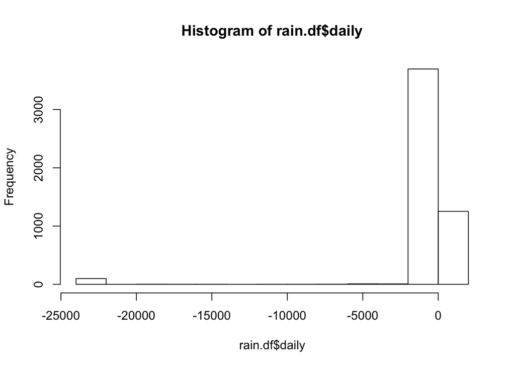

```r
hist(rain.df$daily)
```

8. Create a new data frame rain.df.fixed that takes the original and fixes it for the apparent flaw you have discovered. Having done this, produce a new histogram with the corrected data and explain why this is more reasonable.

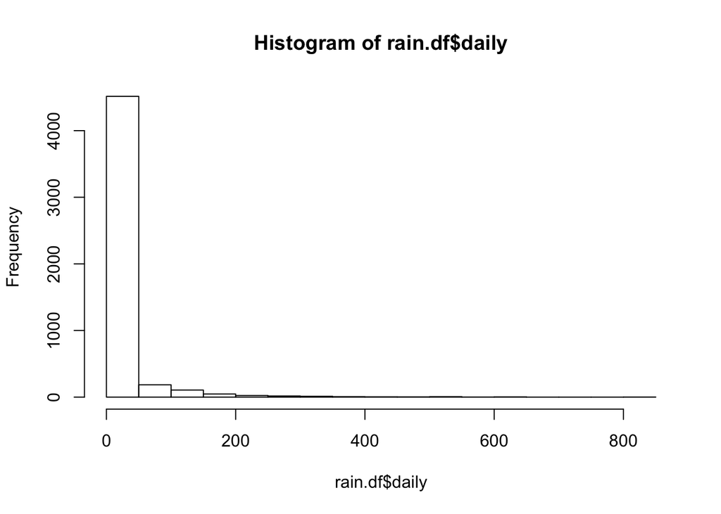

```r
rain.df[rain.df < 0] <- NA
rain.df <- mutate(rain.df, daily = rowSums(select(rain.df, '1':'23')))
hist(rain.df$daily)
```

## Part 2

### New York City Flights 13

- `flights` [336,776 x 16]. Every flight leaving NYC in 2013.
- `weather` [ 8719 x 14]. Hourly Weather Data.
- `planes` [3322 x 9]. Plane data.
- `airports` [1397 x 7]. Airport data.

```r
library(nycflights13)
library(dplyr)
flights=data.frame(flights)
```

### Basic Dplyr

The `dplyr` package uses verbs to perform data manipulation.

- `filter()` and `slice()`
- `arrange()`
- `select()` and `rename()`
- `distinct()`
- `mutate()` and `transmute()`
- `sample_n()` and `sample_frac()`

### Filtering Rows

1. Filter all flights on your birthday.

```r
filter(flights, month==9, day==19)
```

```
##     year month day dep_time sched_dep_time dep_delay arr_time
## 1   2013     9  19       10           2103       187      109
## 2   2013     9  19      447            500       -13      620
## 3   2013     9  19      516            530       -14      759
## 4   2013     9  19      542            545        -3      917
## 5   2013     9  19      545            550        -5      923
## 6   2013     9  19      546            600       -14      649
## 7   2013     9  19      549            600       -11      823
## 8   2013     9  19      550            600       -10     1145
## 9   2013     9  19      551            600        -9      837
## 10  2013     9  19      554            600        -6      728
## 11  2013     9  19      554            600        -6      820
## 12  2013     9  19      554            600        -6      656
## 13  2013     9  19      554            600        -6      658
## 14  2013     9  19      554            600        -6      657
```

[output cut: 2964 more lines]

2. Filter all flights in rows 567 - 589

```r
flights[567:589,]
```

```
##     year month day dep_time sched_dep_time dep_delay arr_time
## 567 2013     1   1     1653           1700        -7     2005
## 568 2013     1   1     1654           1644        10     1752
## 569 2013     1   1     1654           1700        -6     2020
## 570 2013     1   1     1655           1621        34     1804
## 571 2013     1   1     1655           1700        -5     1953
## 572 2013     1   1     1655           1700        -5     2027
## 573 2013     1   1     1655           1655         0     2025
## 574 2013     1   1     1656           1700        -4     1941
## 575 2013     1   1     1657           1650         7     1921
## 576 2013     1   1     1657           1630        27     1948
## 577 2013     1   1     1658           1700        -2     1808
## 578 2013     1   1     1701           1710        -9     2026
## 579 2013     1   1     1701           1700         1     1856
## 580 2013     1   1     1702           1700         2     2044
```

[output cut: 57 more lines]

### Arranging Rows

3. Use arrange() to order the data by year, month and day
4. Use desc() to arrange flights by arrival delay.

### Select

5. Select columns containing data information.
6. Select columns including only plane information.
7. Rename tailnum to tail_num

### Mutating Rows

8. Create a variable called gain which describes the difference between arrival delap and departure delay.
9. Create a variable called speed which is distance over time in hours.

### Summarise

10. Summarise the average delay for all flights.

## Overall Questions

11. Split the complete dataset into individual planes and then summarise each plane by counting the number of flights (count = n()) and computing the average distance and arrival delay . Then plot this:

```
ggplot(delay, aes(dist, delay)) +
  geom_point(aes(size = count), alpha = 1/2) +
  geom_smooth() +
  scale_size_area()
```

12. Find the number of planes and the number of flights that go to each possible destination.

### More Difficult

In the videos we learned about piping our commands. The goal of piping is to help use with the flow of our analysis. The steps we take are: - Think about it. - Describe it. - Do it.

13. Consider the code Below:

```
filter(
  summarise(
    select(
      group_by(flights, year, month, day),
      arr_delay, dep_delay
    ),
    arr = mean(arr_delay, na.rm = TRUE),
    dep = mean(dep_delay, na.rm = TRUE)
  ),
  arr > 30 | dep > 30
)
```

1. What are some problems with this function?
2. How easy is it to follow the logic of this?
3. Rewrite this using piping to make it more understandable.
4. Does your rewritten command give the same results?
14. Consider the code below

```
hourly_delay <- filter(
  summarise(
    group_by(
      filter(
        flights,
        !is.na(dep_delay)
      ),
      date, hour
    ),
    delay=mean(dep_delay),
    n=n()
  ),
  n>10
)
```

1. What are some problems with this function?
2. How easy is it to follow the logic of this?
3. Rewrite this using piping to make it more understandable.
4. Does your rewritten command give the same results?

**Consider how to join information from the other datasets in the package with the current information. Is there a way to tell if weather affected the departure time? Ask yourself other questions about this data and then answer them below.**